# CIS 335: Assignment 1

Stella Sterling

### Part 1 & 2

Data downloaded from Kaggle: https://www.kaggle.com/rajyellow46/wine-quality

### Part 3

There are 13 variables:

| Name | Attribute |
| --- | --- |
| `type` | nominal |
| `fixed acidity` | numeric (ratio) |
| `volatile acidity` | numeric (ratio) |
| `citric acid` | numeric (ratio) |
| `residual sugar` | numeric (ratio) |
| `chlorides` | numeric (ratio) |
| `free sulfur dioxide` | numeric (ratio) |
| `total sulfur dioxide` | numeric (ratio) |
| `density` | numeric (ratio) |
| `pH` | numeric (interval) |
| `sulphates` | numeric (ratio) |
| `alcohol` | numeric (ratio) |
| `quality` | numeric (ratio), discrete could also be considered categorical |

### Part 4

##### Looking at quality points, `quality`:

Summary Stats for Quality Points

| mean | median | mode | IQR |
| --- | --- | --- | --- |
| 5.818378 | 6 | 6 | 1 |

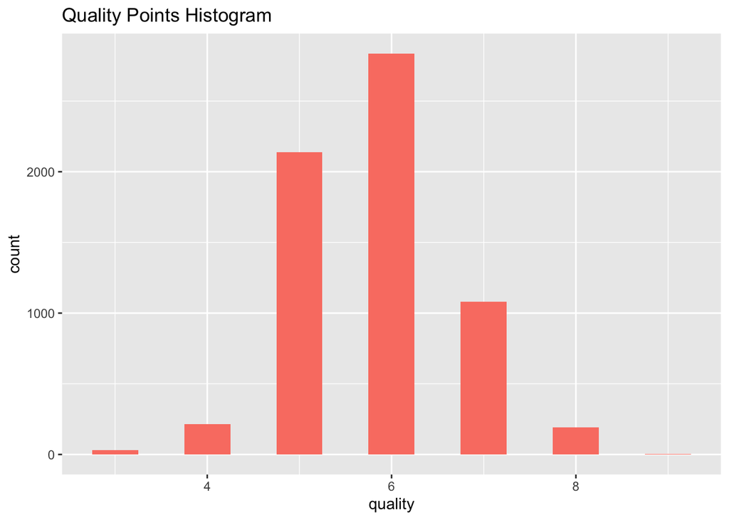

Appears normal; maybe a slight right skew. Will likely treat this as nominal.

##### Looking at fixed acidity, `fixed acidity`:

Summary Stats for Fixed Acidity

| mean | median | mode | IQR |
| --- | --- | --- | --- |
| 7.216579 | 7 | 6.8 | 1.3 |

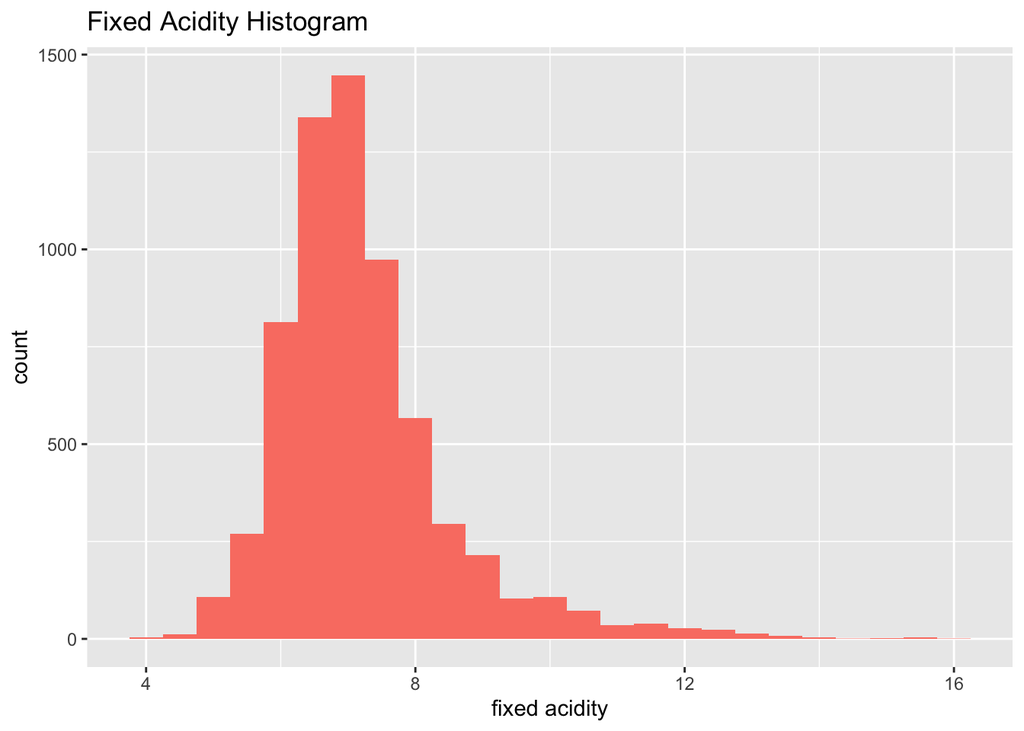

Moderate-high right skew.

##### Looking at alcohol content, `alcohol`:

Summary Stats for Alcohol Content

| mean | median | mode | IQR |
| --- | --- | --- | --- |
| 10.4918 | 10.3 | 9.5 | 1.8 |

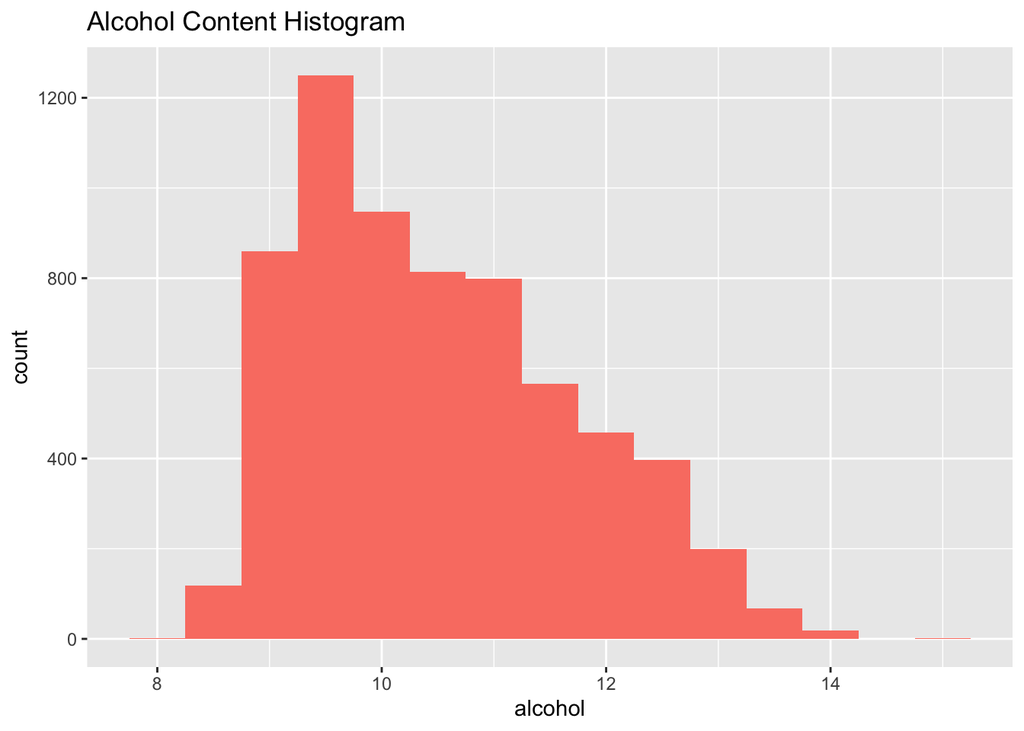

### Part 5

There appears to be outliers certainly looking at the histograms of the fixed acidity and alcohol content. I computed the IQR for those two variables and quality points in the summary statistics tables above.

##### For `quality` the mean = ~5.82 and the IQR = 1.

```r
# minor outlier = + or - IQR*1.5; 1(1.5) = 1.5
5.82-1.5
```

```
## [1] 4.32
```

```r
5.82+1.5
```

```
## [1] 7.32
```

##### For `fixed acidity` the mean = ~7.22 and the IQR = 1.3.

```r
7.22 - 1.5*1.3
```

```
## [1] 5.27
```

```r
7.22 + 1.5*1.3
```

```
## [1] 9.17
```

Values less than 5.27 and greater than 9.17 considered minor outliers. Lots of observations would be removed (~1000). Maybe I would increase my multiplier to 3 and remove major outliers if any? What would the data look like with the minor outliers removed?

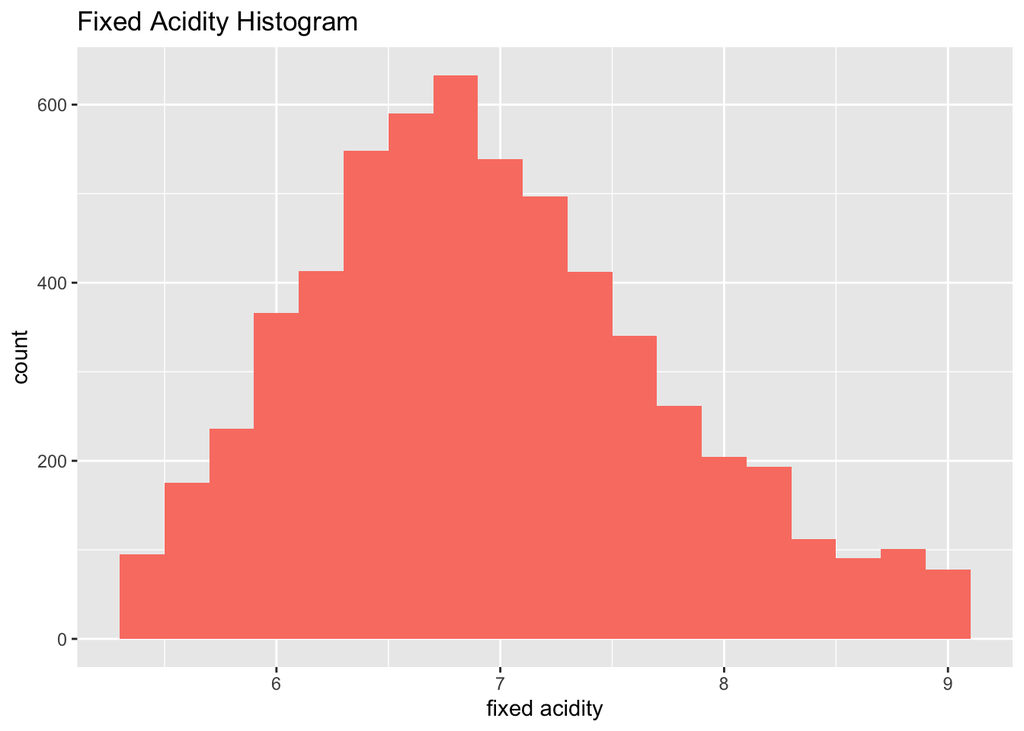

Looks better with these removed, however may consider checking out transformations before removing outliers. This is quite a large data set so I’m not too worried about removing so many observations…

##### For `alcohol` the mean = ~10.49 and the IQR = 1.8.

```r
10.49 - 1.5*1.8
```

```
## [1] 7.79
```

```r
10.49 + 1.5*1.8
```

```
## [1] 13.19
```

Minor outliers would be less than 7.79 and greater than 13.19. This is only about 100 observations and they are pretty close to the edge so I would keep them.

### Part 6

##### Comparing alcohol content (`alcohol`) and `fixed acidity`:

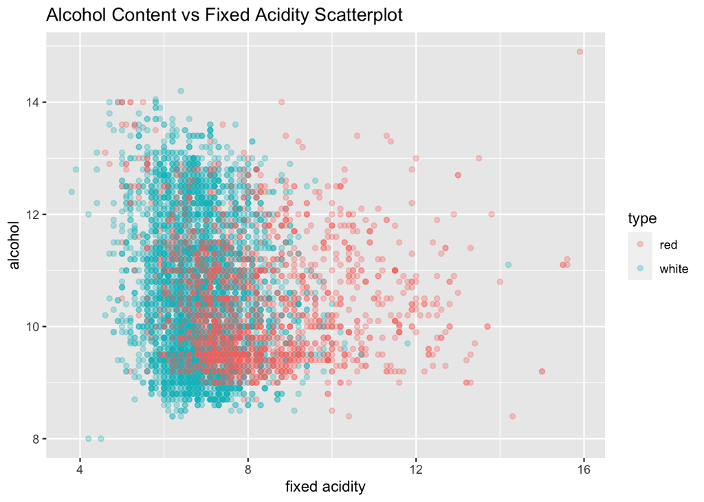

A low-moderate negative correlation. Outliers are definitely an issue. I’ve colored the points for fun because I think in the future it would be cool to see the differences between red and white wines.

##### Comparing alcohol content (`alcohol content`) and ph level (`pH`):

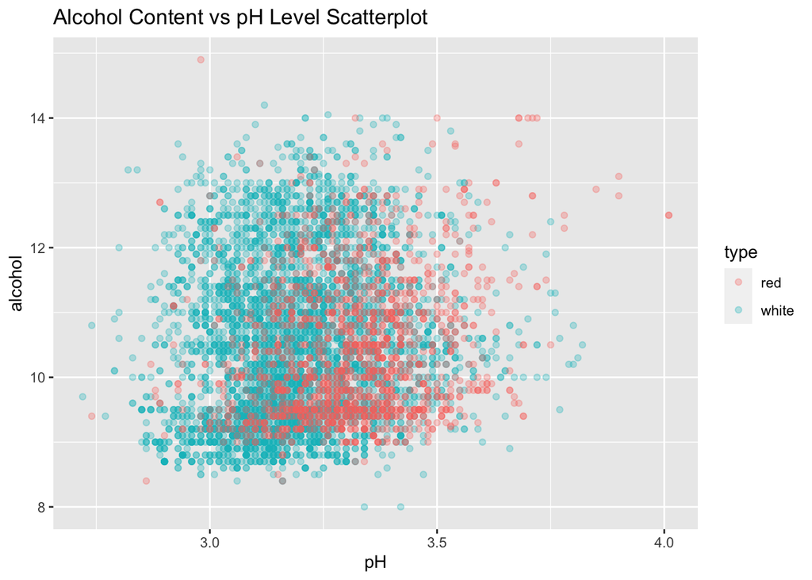

Not seeing much correlation here.

### Part 7

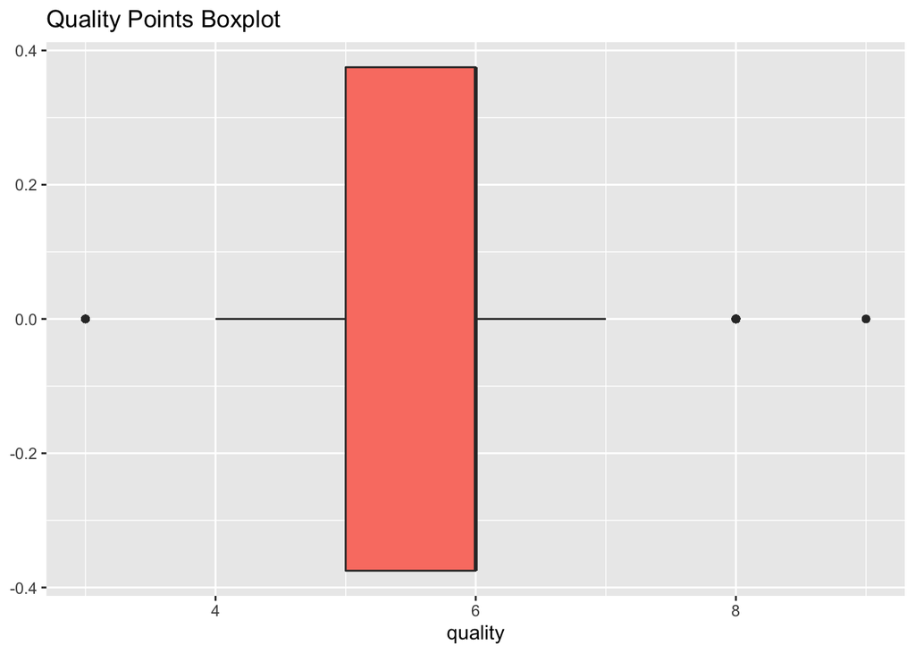

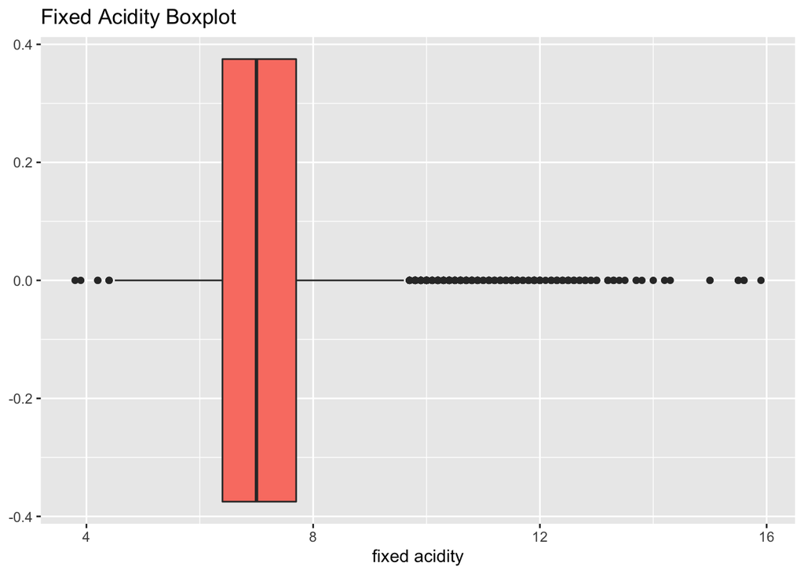

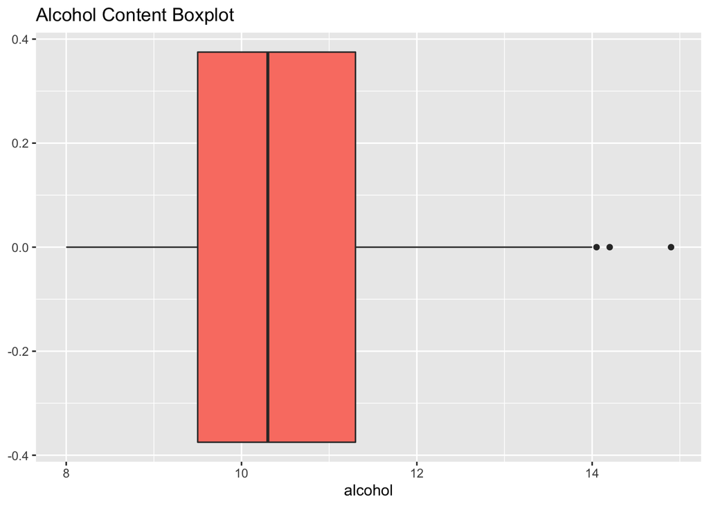